# Establishment Means Analysis

Native, Introduced, and Invasive Species in GBIF

GBIF Gap Analysis Pipeline

April 13, 2026

# Overview

This report analyses the **establishment means** (native, introduced, invasive, naturalised, uncertain) and **occurrence status** (present, absent, doubtful, irregular) of species in the national taxonomy backbone and their representation in GBIF.

Understanding these categories is essential for:

- Correctly interpreting gap analysis results (absent species should not count as “missing”)
- Prioritising monitoring of native species vs tracking invasive spread
- Aligning with CBD Kunming-Montreal Global Biodiversity Framework targets (especially Target 6 on invasive species)

Species coverage by establishment means

| Establishment Means | Species in Backbone | In GBIF | Missing | Coverage % | Total Occurrences |
| --- | --- | --- | --- | --- | --- |
| native | 62,394 | 47,677 | 14,717 | 76.4 | 281,296,042 |
|  | 39,416 | 2,727 | 36,689 | 6.9 | 2,110,905 |
| introduced | 4,755 | 3,579 | 1,176 | 75.3 | 2,675,919 |
| uncertain | 2,819 | 1,035 | 1,784 | 36.7 | 81,190 |
| invasive | 450 | 329 | 121 | 73.1 | 4,050,282 |
| naturalised | 176 | 120 | 56 | 68.2 | 1,280,227 |

Species coverage by occurrence status

| Occurrence Status | Species | In GBIF | Missing | Coverage % |
| --- | --- | --- | --- | --- |
| present | 64,553 | 48,838 | 15,715 | 75.7 |
| (unclassified) | 28,352 | 170 | 28,182 | 0.6 |
| absent | 9,892 | 1,889 | 8,003 | 19.1 |
| irregular | 5,091 | 3,808 | 1,283 | 74.8 |
| doubtful | 2,122 | 762 | 1,360 | 35.9 |

# 1. Coverage by Establishment Means

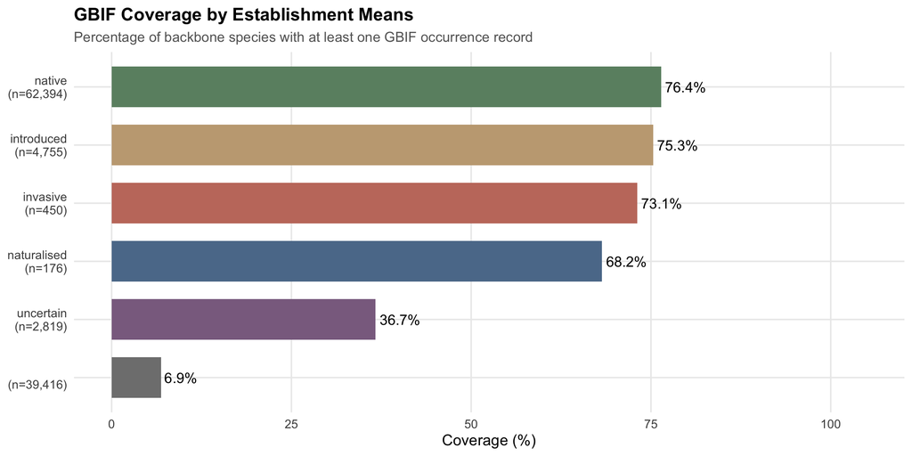

The large gap in coverage for **unclassified species** (those without establishment means in the backbone) is a key finding. These 39,416 species are mostly higher taxa (genera, families) or species with unknown origin. They inflate the overall gap numbers significantly.

**Key insight:** When filtering to **native present species only**, GBIF coverage rises from 50.4% to 76.8%.

# 2. Cross-tabulation: Establishment Means × Occurrence Status

Species count: Establishment Means × Occurrence Status

| establishmentMeans | (unclassified) | absent | doubtful | irregular | present |
| --- | --- | --- | --- | --- | --- |
|  | 28,343 | 8,534 | 377 | 122 | 2,040 |
| introduced | 0 | 39 | 37 | 3,287 | 1,392 |
| invasive | 8 | 82 | 4 | 93 | 263 |
| native | 1 | 227 | 630 | 1,509 | 60,027 |
| naturalised | 0 | 1 | 0 | 5 | 170 |
| uncertain | 0 | 1,009 | 1,074 | 75 | 661 |

# 3. Establishment Means × Threat Status

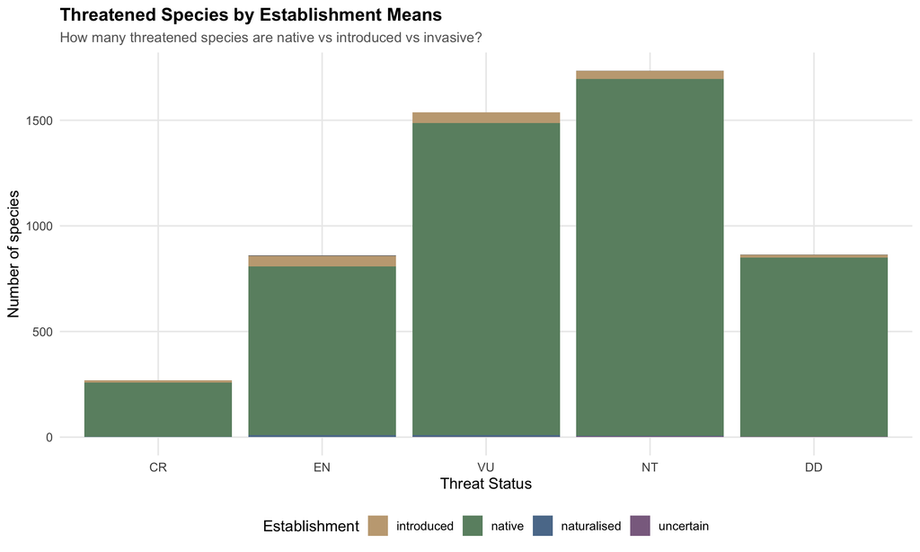

Threatened species coverage by establishment means and threat status

| Establishment | Threat | Species | In GBIF | Coverage % |
| --- | --- | --- | --- | --- |
| native | CR | 258 | 244 | 94.6 |
| introduced | CR | 10 | 9 | 90.0 |
| naturalised | CR | 1 | 1 | 100.0 |
| native | DD | 848 | 757 | 89.3 |
| introduced | DD | 13 | 9 | 69.2 |
| uncertain | DD | 2 | 2 | 100.0 |
|  | DD | 1 | 1 | 100.0 |
| native | EN | 799 | 757 | 94.7 |
| introduced | EN | 49 | 47 | 95.9 |
| naturalised | EN | 10 | 9 | 90.0 |
|  | EN | 2 | 2 | 100.0 |
| native | NT | 1,688 | 1,630 | 96.6 |
| introduced | NT | 38 | 33 | 86.8 |
| uncertain | NT | 4 | 3 | 75.0 |
| naturalised | NT | 3 | 3 | 100.0 |
|  | NT | 1 | 1 | 100.0 |
| native | VU | 1,477 | 1,415 | 95.8 |
| introduced | VU | 51 | 51 | 100.0 |
| naturalised | VU | 9 | 9 | 100.0 |
| uncertain | VU | 1 | 1 | 100.0 |

# 4. Taxonomic Representation: Native vs Invasive

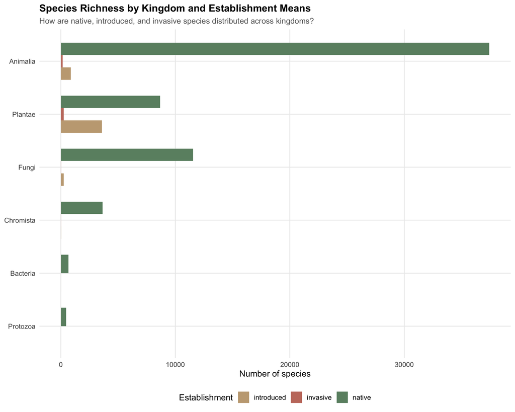

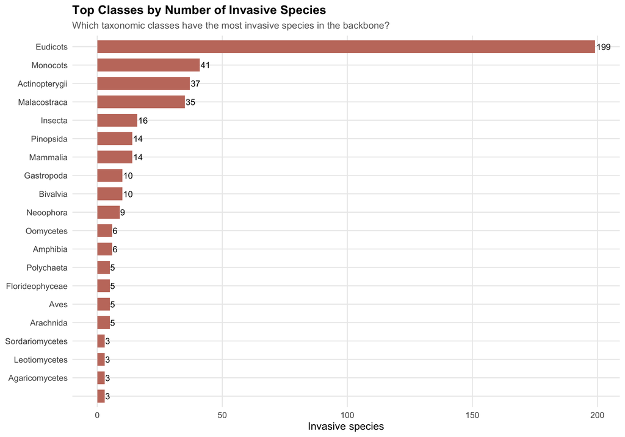

# 5. Sampling Bias: Native vs Invasive

Are invasive species over-represented or under-represented in GBIF relative to their species richness?

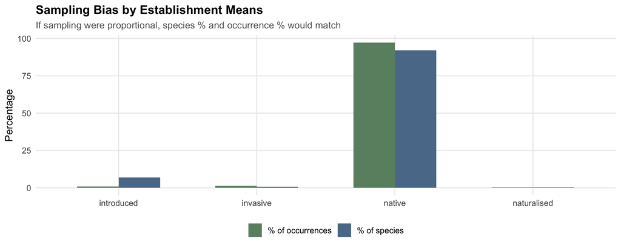

Troudet-style sampling bias by establishment means

| Establishment | Species | Occurrences | % Species | % Occurrences | Bias (occ) |
| --- | --- | --- | --- | --- | --- |
| native | 62,394 | 281,296,042 | 92.1 | 97.2 | 14,962,758 |
| introduced | 4,755 | 2,675,919 | 7.0 | 0.9 | -17,621,141 |
| invasive | 450 | 4,050,282 | 0.7 | 1.4 | 2,129,425 |
| naturalised | 176 | 1,280,227 | 0.3 | 0.4 | 528,958 |

# 6. Spatial Distribution of Invasive Species

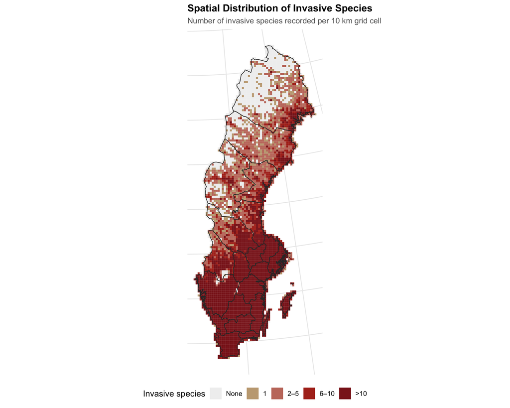

# 7. Native Species: Coverage Gaps by Order

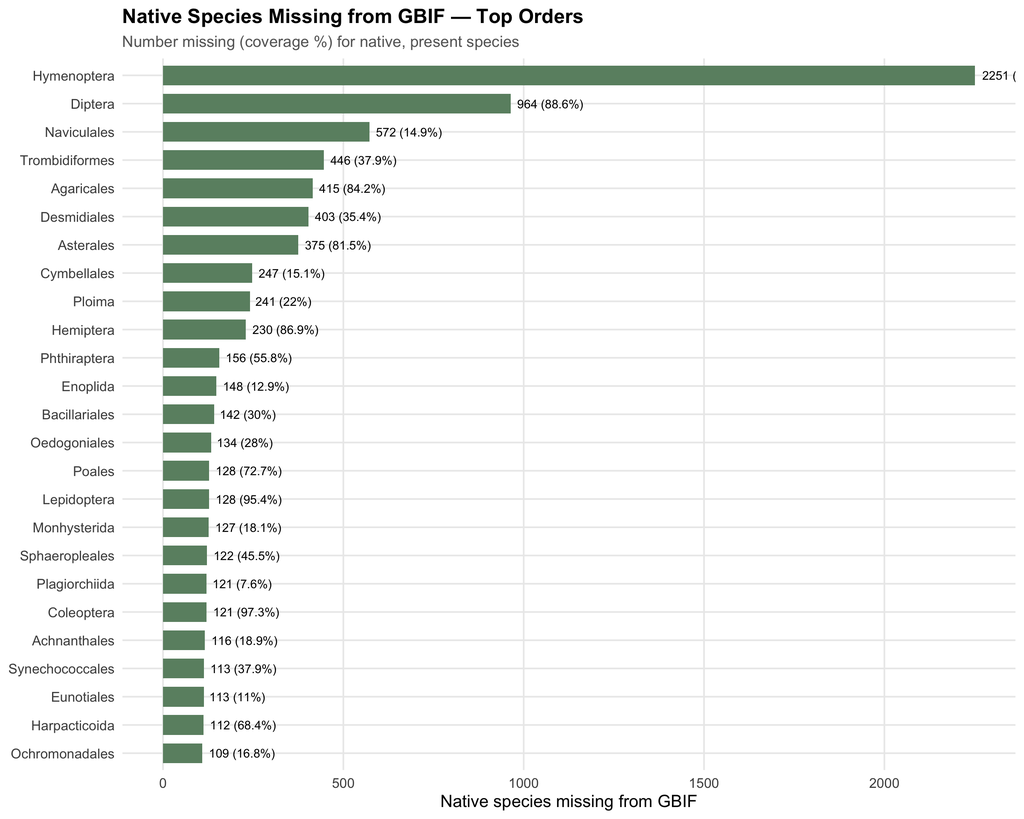

# 8. Invasive Species: Monitoring Gaps

```
## **121 invasive species** in the backbone have no GBIF records.
```

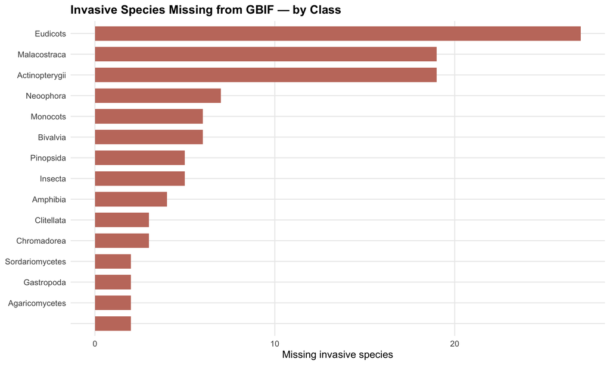

Invasive species missing from GBIF (showing first 50 of 121)

| scientificName | kingdom | class | order | family | threatStatus | occurrenceStatus |
| --- | --- | --- | --- | --- | --- | --- |
| Micropterus salmoides | Animalia | Actinopterygii | Perciformes | Centrarchidae |  | absent |
| Narcissus × incomparabilis | Plantae | Monocots | Asparagales | Amaryllidaceae |  | present |
| Symphyotrichum × versicolor | Plantae | Eudicots | Asterales | Asteraceae |  | irregular |
| Aconogonon × fennicum | Plantae | Eudicots | Caryophyllales | Polygonaceae |  | irregular |
| Reynoutria x bohemica | Plantae | Eudicots | Caryophyllales | Polygonaceae |  | present |
| Epilobium adenocaulon | Plantae | Eudicots | Myrtales | Onagraceae |  | present |
| Laburnum x watereri | Plantae | Eudicots | Fabales | Fabaceae |  | irregular |
| Lupinus × regalis | Plantae | Eudicots | Fabales | Fabaceae |  | irregular |
| Symphytum × uplandicum | Plantae | Eudicots | Boraginales | Boraginaceae |  | present |
| Viola × wittrockiana | Plantae | Eudicots | Malpighiales | Violaceae |  | irregular |
| Larix × marschlinsii | Plantae | Pinopsida | Pinales | Pinaceae |  | irregular |
| Vulpia myuros | Plantae | Monocots | Poales | Poaceae |  | present |
| Bergenia cordifolia | Plantae | Eudicots | Saxifragales | Saxifragaceae |  | irregular |
| Amelanchier spicata | Plantae | Eudicots | Rosales | Rosaceae |  | present |
| Cotoneaster × suecicus | Plantae | Eudicots | Rosales | Rosaceae |  | irregular |
| Spiraea × billardii | Plantae | Eudicots | Rosales | Rosaceae |  | present |
| Spiraea × macrothyrsa | Plantae | Eudicots | Rosales | Rosaceae |  | present |
| Spiraea × rosalba | Plantae | Eudicots | Rosales | Rosaceae |  | present |
| Spiraea × rubella | Plantae | Eudicots | Rosales | Rosaceae |  | present |
| Spiraea latifolia | Plantae | Eudicots | Rosales | Rosaceae |  | present |
| Populus × wettsteinii | Plantae | Eudicots | Malpighiales | Salicaceae |  | irregular |
| Hyacinthoides × massartiana | Plantae | Monocots | Asparagales | Asparagaceae |  | irregular |
| Brassica rapa subsp. oleifera | Plantae | Eudicots | Brassicales | Brassicaceae |  | irregular |
| Genista tinctoria subsp. elatior | Plantae | Eudicots | Fabales | Fabaceae |  | irregular |
| Larix decidua subsp. decidua | Plantae | Pinopsida | Pinales | Pinaceae |  | present |
| Picea × lutzii | Plantae | Pinopsida | Pinales | Pinaceae |  | irregular |
| Pinus mugo subsp. × rotundata | Plantae | Pinopsida | Pinales | Pinaceae |  | irregular |
| Aronia × prunifolia | Plantae | Eudicots | Rosales | Rosaceae |  | irregular |
| Ophiostoma ulmi s.lat. | Fungi | Sordariomycetes | Ophiostomatales | Ophiostomataceae |  | present |
| Anoplophora glabripennis | Animalia | Insecta | Coleoptera | Cerambycidae |  | absent |
| Pseudodactylogyrus bini | Animalia | Neoophora | Dactylogyridea | Dactylogyridae |  | present |
| Undaria pinnatifida | Chromista | Phaeophyceae | Laminariales | Alariaceae |  | absent |
| Paratenuisentis ambiguus | Animalia | Eoacanthocephala | Neoechinorhynchida | Tenuisentidae |  | absent |
| Paramysis lacustris | Animalia | Malacostraca | Mysida | Mysidae |  | absent |
| Echinogammarus ischnus | Animalia | Malacostraca | Amphipoda | Gammaridae |  | absent |
| Echinogammarus warpachowskyi | Animalia | Malacostraca | Amphipoda | Gammaridae |  | absent |
| Gmelinoides fasciatus | Animalia | Malacostraca | Amphipoda | Micruropodidae |  | absent |
| Faxonius limosus | Animalia | Malacostraca | Decapoda | Cambaridae |  | absent |
| Palaemon macrodactylus | Animalia | Malacostraca | Decapoda | Palaemonidae |  | absent |
| Corbicula fluminea | Animalia | Bivalvia | Veneroida | Cyrenidae |  | absent |
| Dreissena bugensis | Animalia | Bivalvia | Veneroida | Dreissenidae |  | absent |
| Rapana venosa | Animalia | Gastropoda | Neogastropoda | Muricidae |  | absent |
| Botrylloides violaceus | Animalia |  | Stolidobranchiata | Styelidae |  | absent |
| Babka gymnotrachelus | Animalia | Actinopterygii | Perciformes | Gobiidae |  | absent |
| Perccottus glenii | Animalia | Actinopterygii | Perciformes | Odontobutidae |  | absent |
| Narcissus pseudonarcissus subsp. major | Plantae | Monocots | Asparagales | Amaryllidaceae |  | irregular |
| Narcissus pseudonarcissus var. plenus | Plantae | Monocots | Asparagales | Amaryllidaceae |  | present |
| Hippocrepis emerus subsp. emeroides | Plantae | Eudicots | Fabales | Fabaceae |  | present |
| Dasiphora fruticosa subsp. floribunda | Plantae | Eudicots | Rosales | Rosaceae |  | irregular |
| Ilex × meserveae | Plantae | Eudicots | Aquifoliales | Aquifoliaceae |  | irregular |

# 9. Summary and Recommendations

**Key findings:**

- **60,027** native present species — 76.8% have GBIF records
- **450** invasive species — 73.1% have GBIF records, **121** lack any data
- **39,416** species lack establishment means classification — these inflate gap numbers (only 6% have GBIF records)

*Report generated by the gbifgaps pipeline. See `ROADMAP.md` for development plans.*